# Exam Scores Data Exploration

## by Eddington Obaro Jonathan

## Preliminary Wrangling

This document explores a dataset containing exam scores for approximately 1000 students.

```python
# Importing needed libraries
import pandas as pd
import numpy as np
import matplotlib.pyplot as plt
from matplotlib import rcParams
import seaborn as sns
%matplotlib inline
```

```python
df = pd.read_csv('exams.csv')
df.head()
```

|  | gender | race/ethnicity | parental level of education | lunch | test preparation course | math score | reading score | writing score |
| --- | --- | --- | --- | --- | --- | --- | --- | --- |
| 0 | male | group A | high school | standard | completed | 67 | 67 | 63 |
| 1 | female | group D | some high school | free/reduced | none | 40 | 59 | 55 |
| 2 | male | group E | some college | free/reduced | none | 59 | 60 | 50 |
| 3 | male | group B | high school | standard | none | 77 | 78 | 68 |
| 4 | male | group E | associate's degree | standard | completed | 78 | 73 | 68 |

```python
df.shape
```

```
(1000, 8)
```

```python
df.info()
```

```
<class 'pandas.core.frame.DataFrame'>
RangeIndex: 1000 entries, 0 to 999
Data columns (total 8 columns):
 #   Column                       Non-Null Count  Dtype
---  ------                       --------------  -----
 0   gender                       1000 non-null   object
 1   race/ethnicity               1000 non-null   object
 2   parental level of education  1000 non-null   object
 3   lunch                        1000 non-null   object
 4   test preparation course      1000 non-null   object
 5   math score                   1000 non-null   int64
 6   reading score                1000 non-null   int64
 7   writing score                1000 non-null   int64
dtypes: int64(3), object(5)
memory usage: 62.6+ KB
```

```python
df.isnull().sum()
```

```
gender                         0
race/ethnicity                 0
parental level of education    0
lunch                          0
test preparation course        0
math score                     0
reading score                  0
writing score                  0
dtype: int64
```

```python
df.duplicated().sum()
```

```
1
```

```python
df[df.duplicated()==True]
```

|  | gender | race/ethnicity | parental level of education | lunch | test preparation course | math score | reading score | writing score |
| --- | --- | --- | --- | --- | --- | --- | --- | --- |
| 825 | male | group E | associate's degree | standard | completed | 100 | 100 | 100 |

```python
#  Dropping duplicates
df.drop_duplicates(inplace=True, ignore_index=True)
```

```python
df.shape
```

```
(999, 8)
```

```python
df.head(20)
```

|  | gender | race/ethnicity | parental level of education | lunch | test preparation course | math score | reading score | writing score |
| --- | --- | --- | --- | --- | --- | --- | --- | --- |
| 0 | male | group A | high school | standard | completed | 67 | 67 | 63 |
| 1 | female | group D | some high school | free/reduced | none | 40 | 59 | 55 |
| 2 | male | group E | some college | free/reduced | none | 59 | 60 | 50 |
| 3 | male | group B | high school | standard | none | 77 | 78 | 68 |
| 4 | male | group E | associate's degree | standard | completed | 78 | 73 | 68 |
| 5 | female | group D | high school | standard | none | 63 | 77 | 76 |
| 6 | female | group A | bachelor's degree | standard | none | 62 | 59 | 63 |
| 7 | male | group E | some college | standard | completed | 93 | 88 | 84 |
| 8 | male | group D | high school | standard | none | 63 | 56 | 65 |
| 9 | male | group C | some college | free/reduced | none | 47 | 42 | 45 |
| 10 | male | group E | some college | standard | completed | 99 | 83 | 85 |
| 11 | female | group D | high school | standard | completed | 80 | 87 | 90 |
| 12 | male | group D | associate's degree | standard | completed | 77 | 87 | 85 |
| 13 | male | group C | high school | standard | completed | 74 | 74 | 73 |
| 14 | male | group E | some high school | standard | completed | 81 | 87 | 85 |
| 15 | male | group E | associate's degree | free/reduced | none | 69 | 61 | 57 |
| 16 | male | group B | high school | standard | none | 58 | 47 | 42 |
| 17 | female | group C | associate's degree | standard | completed | 54 | 62 | 65 |
| 18 | female | group C | associate's degree | free/reduced | none | 23 | 44 | 44 |
| 19 | male | group C | some college | free/reduced | none | 39 | 32 | 31 |

```python
df.describe()
```

|  | math score | reading score | writing score |
| --- | --- | --- | --- |
| count | 999.000000 | 999.000000 | 999.000000 |
| mean | 66.362362 | 68.970971 | 67.705706 |
| std | 15.373794 | 14.711935 | 15.575322 |
| min | 13.000000 | 27.000000 | 23.000000 |
| 25% | 56.000000 | 60.000000 | 58.000000 |
| 50% | 66.000000 | 70.000000 | 68.000000 |
| 75% | 77.000000 | 79.000000 | 79.000000 |
| max | 100.000000 | 100.000000 | 100.000000 |

```python
# Creating a new column called 'average_score'
df['average score'] = (round((df['math score']+df['reading score']+df['writing score'])/3,1))
df.head()
```

|  | gender | race/ethnicity | parental level of education | lunch | test preparation course | math score | reading score | writing score | average score |
| --- | --- | --- | --- | --- | --- | --- | --- | --- | --- |
| 0 | male | group A | high school | standard | completed | 67 | 67 | 63 | 65.7 |
| 1 | female | group D | some high school | free/reduced | none | 40 | 59 | 55 | 51.3 |
| 2 | male | group E | some college | free/reduced | none | 59 | 60 | 50 | 56.3 |
| 3 | male | group B | high school | standard | none | 77 | 78 | 68 | 74.3 |
| 4 | male | group E | associate's degree | standard | completed | 78 | 73 | 68 | 73.0 |

```python
df.shape
```

```
(999, 9)
```

```python
df.describe()
```

|  | math score | reading score | writing score | average score |
| --- | --- | --- | --- | --- |
| count | 999.000000 | 999.000000 | 999.000000 | 999.000000 |
| mean | 66.362362 | 68.970971 | 67.705706 | 67.679680 |
| std | 15.373794 | 14.711935 | 15.575322 | 14.484281 |
| min | 13.000000 | 27.000000 | 23.000000 | 21.700000 |
| 25% | 56.000000 | 60.000000 | 58.000000 | 58.500000 |
| 50% | 66.000000 | 70.000000 | 68.000000 | 67.300000 |
| 75% | 77.000000 | 79.000000 | 79.000000 | 78.300000 |
| max | 100.000000 | 100.000000 | 100.000000 | 100.000000 |

```python
# Saving thee cleaned dataset
df.to_csv('cleaned_exam.csv')
```

# What is the structure of your dataset?

There are 999 students' exam scores in three subjects (math, reading and writing). The dataset contains 999 observations and 9 variables. The variables include: 'gender', 'race/ethnicity', 'parental level of education', 'lunch', 'test preparation course', 'math score', 'reading score', 'writing score' and 'average_score'. There are four numrical variables (which include 'math score', 'reading score', 'writing score' and 'average_score') and five categorical variables (which include 'gender', 'race/ethnicity', 'parental level of education', 'lunch', and 'test preparation course') in the dataset.

The categorical variables in the dataset are nominal while the numerical variables are discrete.

# What is/are the main feature(s) of interest in your dataset?¶

I'm most interested in figuring out what features are best for predicting students' performance in the dataset.

# What features in the dataset do you think will help support your investigation into your feature(s) of interest?

I expect that test preparation course will have the strongest effect on each student's performance: I believe that those students who completed a test preparation course will perform better than those who did not. I also think that parental level of education will have some effects on each student's performance: the higher the parental level of education, the better the performance.

```python
# defining functions for plotting visuals.
def univariate_visualization(variable_in_quotes):
    numerical_var = df.columns[5:]
    bar_chart_variables = ['parental level of education', 'race/ethnicity']

    if variable_in_quotes in numerical_var:
        plt.figure(figsize=[10, 6])
        bins = np.arange(10, df[variable_in_quotes].max()+5, 5)
        ticks = np.arange(10, df[variable_in_quotes].max()+10, 10)
        labels = [f'{int(i)}' for i in ticks]
        plt.hist(data=df, x=variable_in_quotes, bins=bins)
        plt.xticks(ticks, labels)
        plt.title(f'Distribution of {variable_in_quotes}'.upper(), fontsize=14, y=1.05)
        plt.xlabel(variable_in_quotes, fontsize=12)
        plt.ylabel('count', fontsize=12);
    else:
        if variable_in_quotes in bar_chart_variables:
            rcParams['figure.figsize'] = 8,5
            plt.title(f'Distribution of {variable_in_quotes}'.upper(), y=1.05, fontsize=14)
            count_order = df[variable_in_quotes].value_counts()
            sns.countplot(data = df, y = variable_in_quotes, color=sns.color_palette()[0], order = count_order.index);
            rcParams['figure.figsize'] = 8,5
            for i in range(count_order.shape[0]):
                count = count_order[i]
                bar_prop_label = f'{round((count/count_order.sum())*100,1)}%'
                plt.text(count+1, i, bar_prop_label, va='center')
        else:
            plt.figure(figsize=[7,7])
            rcParams['font.size']=16
            if variable_in_quotes == 'test preparation course':
                labels=['not completed', 'completed']
                colors=['#0b0918','#10485288']
            elif variable_in_quotes == 'gender':
                labels = ['Male', 'Female']
                colors=['#0d1335', '#bc5090']
            elif variable_in_quotes == 'lunch':
                labels = ['standard', 'free/reduced']
                colors=['#003f5c', '#bc5090']
            _, _, autotexts = plt.pie(df[variable_in_quotes].value_counts(), labels=labels, colors=colors,
                                      startangle=90, counterclock=False, shadow=True, explode=(0, 0.08), autopct='%1.1f%%')
            for figure in autotexts:
                figure.set_color('white')
            plt.title(variable_in_quotes.upper())
    plt.show;

def bivariate_visualization(numerical_var_in_quotes, categorical_var_in_quotes):
    if categorical_var_in_quotes == 'race/ethnicity' or categorical_var_in_quotes == 'parental level of education':
        size = (6,25)
        nrows = 3
        ncols = 1
        fontsize = 12
        rotation=10
        x = categorical_var_in_quotes
        y = numerical_var_in_quotes
        bar_palette=['#003f5c']
        if categorical_var_in_quotes == 'parental level of education':
            xlabel = ''
        else:
            xlabel = categorical_var_in_quotes
    else:
        size = (22,6)
        nrows = 1
        ncols = 3
        fontsize=18
        rotation=0
        x = categorical_var_in_quotes
        y = numerical_var_in_quotes
        bar_palette=['#003f5c', '#bc5090']
        xlabel = categorical_var_in_quotes

    sns.set(rc={'figure.figsize':size})
    plt.subplot(nrows, ncols, 1)
    plt.title(f'Box Plot of {numerical_var_in_quotes} for {categorical_var_in_quotes}'.upper(), fontsize=12, y=1.05)
    sns.boxplot(data = df, y = y, x = x, color = sns.color_palette()[-1], palette=['#003f5c', '#bc5090'])
    plt.xlabel(xlabel, fontsize=fontsize)
    plt.ylabel(numerical_var_in_quotes, fontsize= fontsize)
    plt.xticks(fontsize= fontsize, rotation=rotation)

    plt.subplot(nrows, ncols, 2)
    plt.title(f'Violin Plot of {numerical_var_in_quotes} for {categorical_var_in_quotes}'.upper(), fontsize=12, y=1.05)
    sns.violinplot(data = df, y = y, x = x, palette=['#003f5c', '#bc5090'], inner='quartile')
    plt.xlabel(xlabel, fontsize=fontsize)
    plt.ylabel(numerical_var_in_quotes, fontsize=fontsize)
    plt.xticks(fontsize= fontsize, rotation=rotation)

    plt.subplot(nrows, ncols, 3)
    plt.title(f'Bar Chart of {numerical_var_in_quotes} for {categorical_var_in_quotes}'.upper(), fontsize=12, y=1.05)
    sns.barplot(data = df, x = categorical_var_in_quotes, y = numerical_var_in_quotes, palette = bar_palette)
    plt.xlabel(categorical_var_in_quotes, fontsize=fontsize)
    plt.ylabel(numerical_var_in_quotes, fontsize=fontsize)
    plt.xticks(fontsize= fontsize, rotation=90)
    plt.show;

def multivariate_violin(numerical_var_in_quotes, categorical_var_in_qoutes, categorical_hue_in_quotes):
    rcParams['figure.figsize']= 10,6
    sns.violinplot(data=df, x=categorical_var_in_qoutes, y=numerical_var_in_quotes, hue=categorical_hue_in_quotes, inner='quartile', palette=['#bc5090','#10485288'], split=True)
    plt.xlabel(categorical_var_in_qoutes)
    plt.ylabel(numerical_var_in_quotes)
    plt.title(f'Violin plot of {numerical_var_in_quotes} of {categorical_var_in_qoutes} based on their {categorical_hue_in_quotes} status'.upper())
    plt.show();
```

# UNIVARIATE EXPLORATION

## Distribution of math score, reading score and writing score

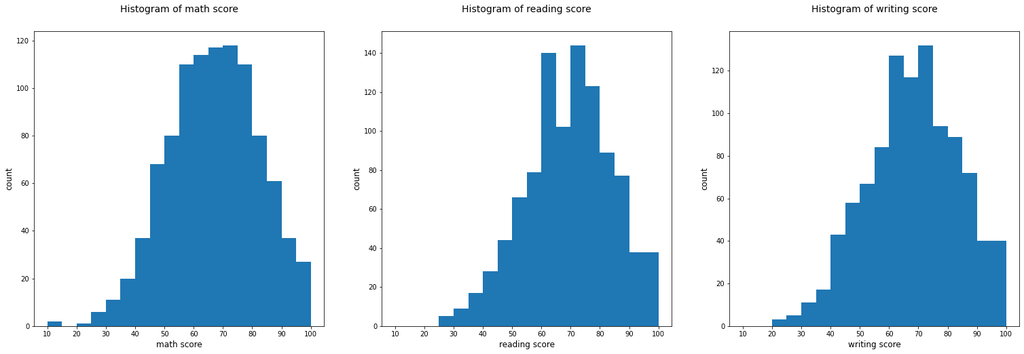

```python
plt.figure(figsize=[26, 8])

plt.subplot(1, 3, 1)
bins = np.arange(10, df['math score'].max()+5, 5)
ticks = np.arange(10, df['math score'].max()+10, 10)
labels = [f'{i}' for i in ticks]
plt.hist(data=df, x='math score', bins=bins)
plt.xticks(ticks, labels)
plt.title('Histogram of math score', fontsize=14, y=1.05)
plt.xlabel('math score', fontsize=12)
plt.ylabel('count', fontsize=12)


plt.subplot(1, 3, 2)
bins = np.arange(10, df['reading score'].max()+5, 5)
ticks = np.arange(10, df['reading score'].max()+10, 10)
labels = [f'{i}' for i in ticks]
plt.hist(data=df, x='reading score', bins=bins)
plt.xticks(ticks, labels)
plt.title('Histogram of reading score', fontsize=14, y=1.05)
plt.xlabel('reading score', fontsize=12)
plt.ylabel('count', fontsize=12)


plt.subplot(1, 3, 3)
bins = np.arange(10, df['writing score'].max()+5, 5)
ticks = np.arange(10, df['writing score'].max()+10, 10)
labels = [f'{i}' for i in ticks]
plt.hist(data=df, x='writing score', bins=bins)
plt.xticks(ticks, labels)
plt.title('Histogram of writing score', fontsize=14, y=1.05)
plt.xlabel('writing score', fontsize=12)
plt.ylabel('count', fontsize=12)

plt.show;
```

All three disribution (mathe score, reading score and writing score) are left-skewed indicating that most students scored above 50 percent. However, there are students who scored lesss than 30 percent. Math got the least score.

## Distribution of average score

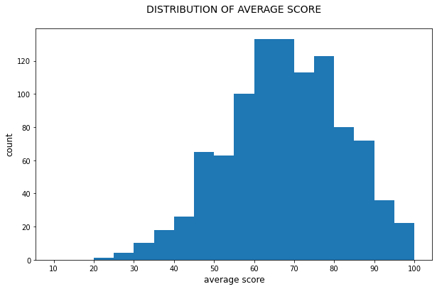

```python
univariate_visualization('average score')
```

Just like the other numerical variables, the average score of the students is left-skewed, indicating that most students scored above 50 percent.

## Distribution of test preparation course

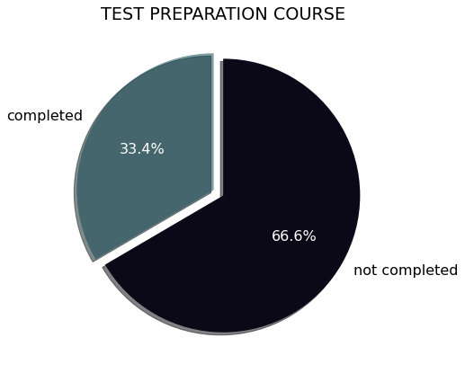

```python
univariate_visualization('test preparation course')
```

About one-third of the students completed a test prepararion course.

## Distribution of gender

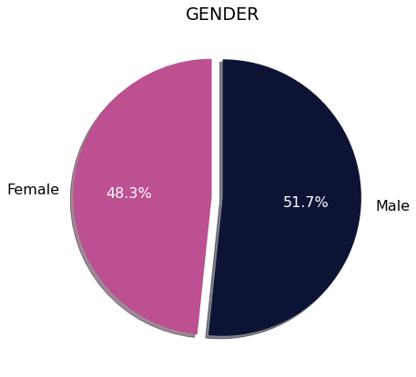

```python
univariate_visualization('gender')
```

Male students were slightly more than female students by about 3 percent.

## Distribution of lunch

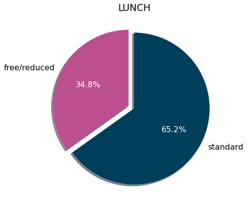

```python
univariate_visualization('lunch')
```

Close to two-third of the students had standard lunch while slightly above one-third had free or reduced lunch.

## Distribution of parental level of education

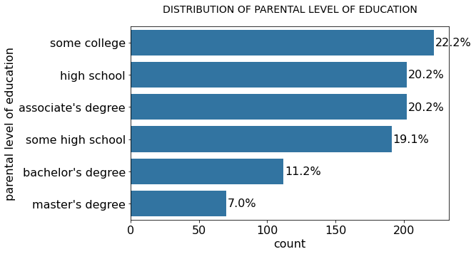

```python
univariate_visualization('parental level of education')
```

About 7 percent of the students are children of master's degree holder, representing the least number in the parental level of education.

## Distribution of race/ethnicity

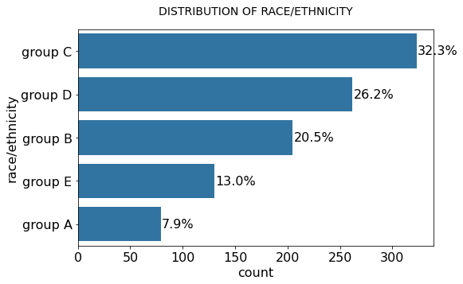

```python
univariate_visualization('race/ethnicity')
```

Group c race/enthnicity had the highest number of student while group A had the least number of students.

## Discuss the distribution(s) of your variable(s) of interest. Were there any unusual points? Did you need to perform any transformations?

About one-third of the students completed a test prepararion course. The numerical variables are left-skewed. This is typical of exam scores. The writing score and the reading score are bimodal.

## Of the features you investigated, were there any unusual distributions? Did you perform any operations on the data to tidy, adjust, or change the form of the data? If so, why did you do this?

During the wrangling phase, I calculated the average score for each student and stored it in a variable called 'average score'. I assumed that doing this would make my analysis easier.

# BIVARIATE EXPLORATION

## COMPARING PERFORMANCE BASED ON GENDER

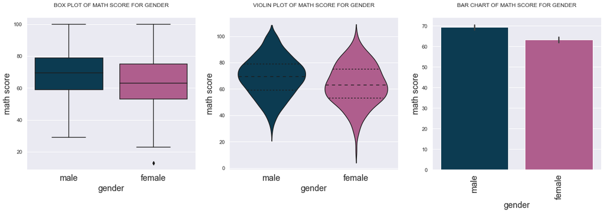

```python
bivariate_visualization('math score', 'gender')
```

Male students performed better in math than female students.

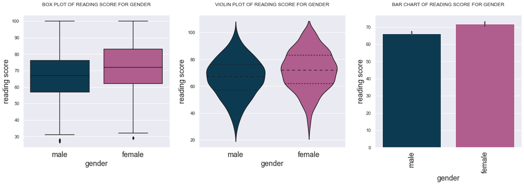

```python
bivariate_visualization('reading score', 'gender')
```

Female students performed better in reading than male students.

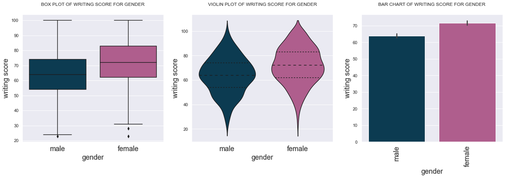

```python
bivariate_visualization('writing score', 'gender')
```

Female students also performed better in writing than male students.

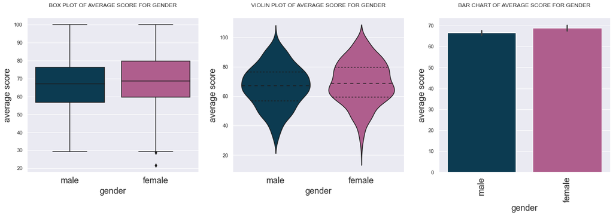

```python
bivariate_visualization('average score', 'gender')
```

On the average, female students performed slightly better than male students.

## COMPARING PERFORMANCE BASED ON COMPLETION OF TEST PREPARATION COURSE

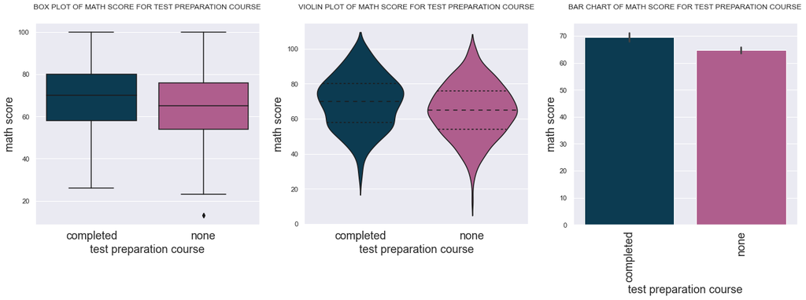

```python
bivariate_visualization('math score', 'test preparation course')
```

Students who completed a test preparation course performed better in math than those who did not.

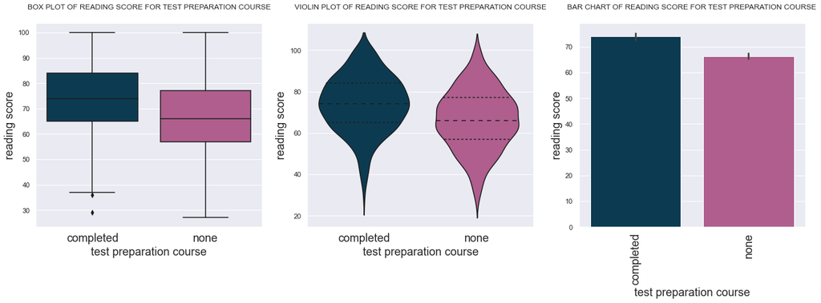

```python
bivariate_visualization('reading score', 'test preparation course')
```

Students who completed a test preparation course performed better in reading than those who did not.

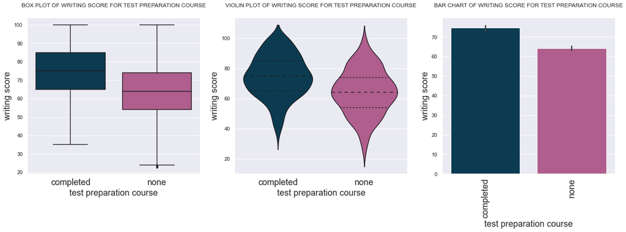

```python
bivariate_visualization('writing score', 'test preparation course')
```

Students who completed a test preparation course performed better in writing than those who did not.

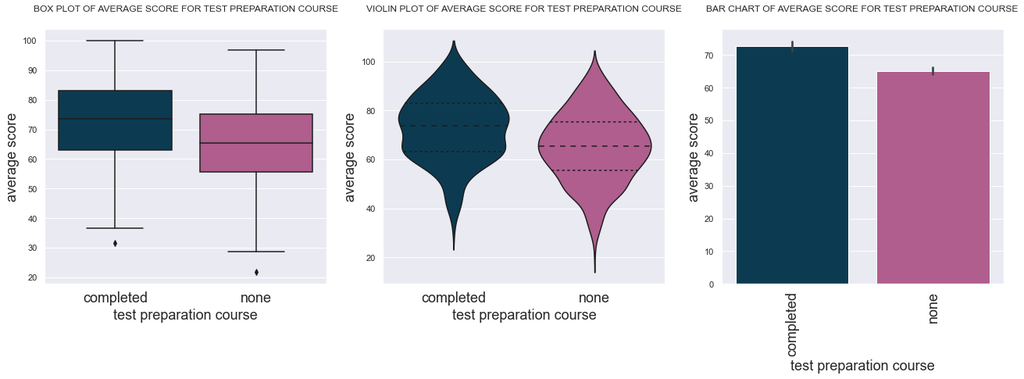

```python
bivariate_visualization('average score', 'test preparation course')
```

On the average, students who completed a test preparation course performed better than those who did not.

## COMPARING PERFORMANCE BASED ON LUNCH

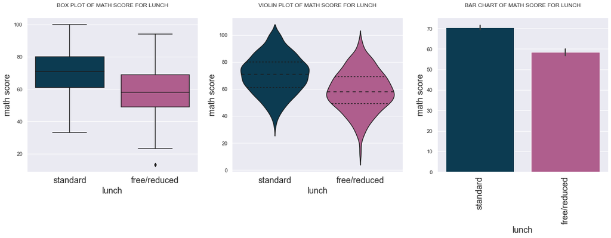

```python
bivariate_visualization('math score', 'lunch')
```

Students who had standard lunch performed better in math than those who had free or reduced lunch.

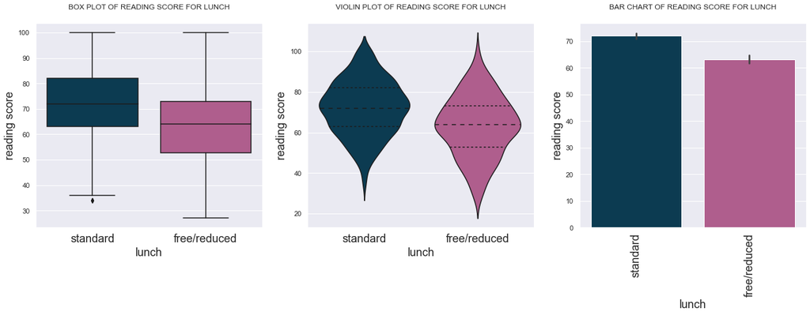

```python
bivariate_visualization('reading score', 'lunch')
```

Students who had standard lunch performed better in reading than those who had free or reduced lunch.

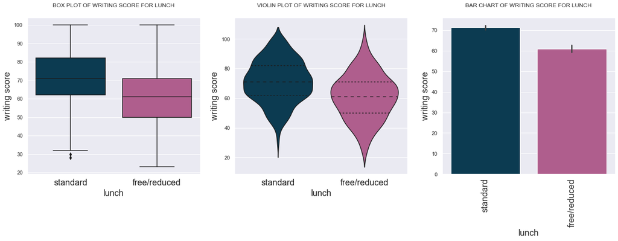

```python
bivariate_visualization('writing score', 'lunch')
```

Students who had standard lunch performed better in writing than those who had free or reduced lunch.

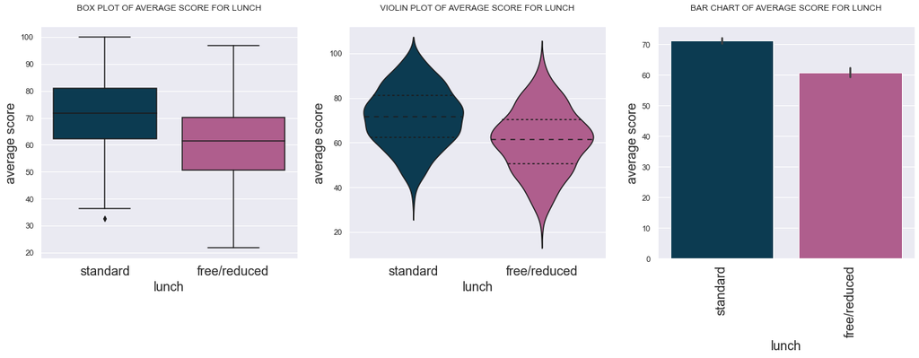

```python
bivariate_visualization('average score', 'lunch')
```

On the average, students who had standard lunch performed better than those who had free or reduced lunch.

## COMPARING PERFORMANCE BASED ON RACE/ETHNICITY

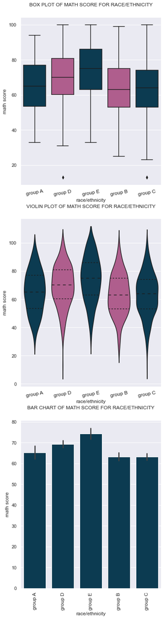

```python
bivariate_visualization('math score', 'race/ethnicity')
```

Group E race/ethnicity had the best performance in math.

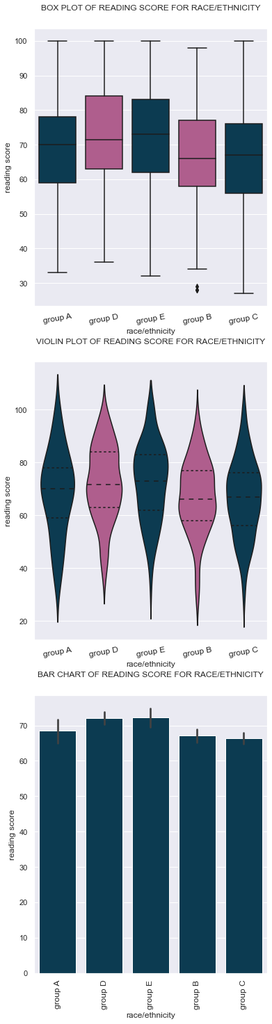

```python
bivariate_visualization('reading score', 'race/ethnicity')
```

Groups D and E race/ethnicity had the best performance in reading.

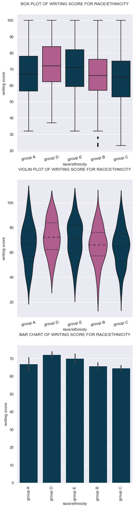

```python
bivariate_visualization('writing score', 'race/ethnicity')
```

Group D race/ethnicity had the best performance in writing.

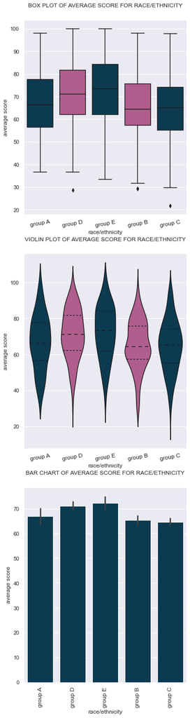

```python
bivariate_visualization('average score', 'race/ethnicity')
```

On the average, Group E race/ethnicity had the best performance.

## COMPARING PERFORMANCE BASED ON PARENTAL LEVEL OF EDUCATION

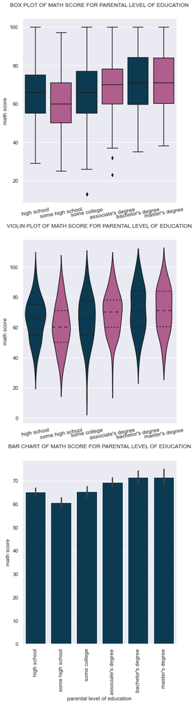

```python
bivariate_visualization('math score', 'parental level of education')
```

Students whose parents possess a master's degree or a bachelor's degree performed better in math than other students.

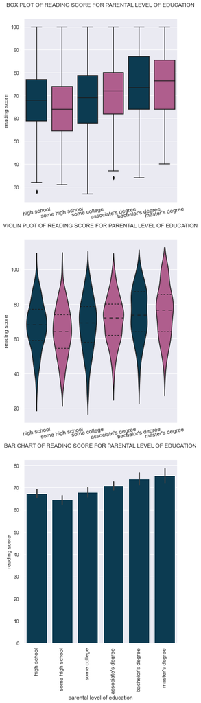

```python
bivariate_visualization('reading score', 'parental level of education')
```

Students whose parents possess a master's degree or a bachelor's degree performed better in reading than other students.

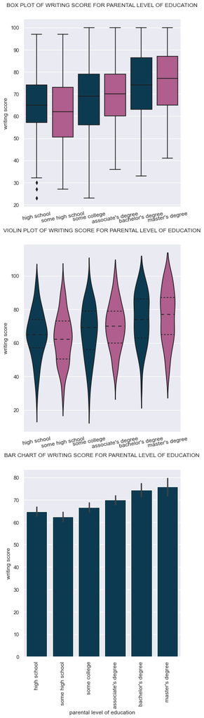

```python
bivariate_visualization('writing score', 'parental level of education')
```

Students whose parents possess a master's degree or a bachelor's degree performed better in writing than other students.

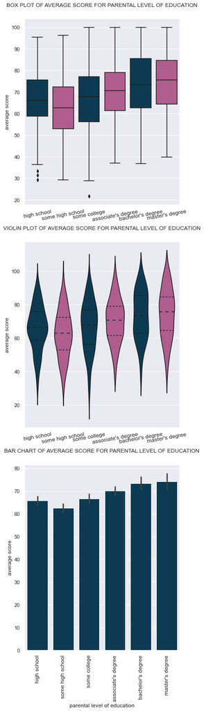

```python
bivariate_visualization('average score', 'parental level of education')
```

On the average, students whose parents possess a master's degree or a bachelor's degree performed better than other students.

## Correlation among the numerical variables

I will now explore the relationship between the numerical variables by calculating the correlation matrix.

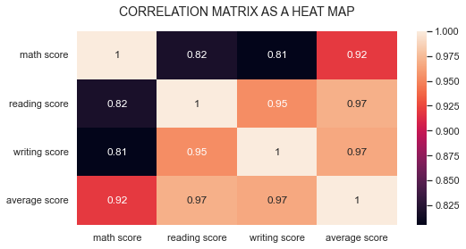

```python
corr_df = df.corr()
sns.set(rc={'figure.figsize':(8,4)})
sns.heatmap(corr_df, annot=True)
plt.title('Correlation matrix as a heat map'.upper(), fontsize=14, y=1.05)
plt.show;
```

There is a very high correation between the three subjects. Students who performed excellently well in one subject also performed excellently well in the two other subjects and vice versa. The relationship between reding and writing is especially noticeable. There is need to observe this relationship further.

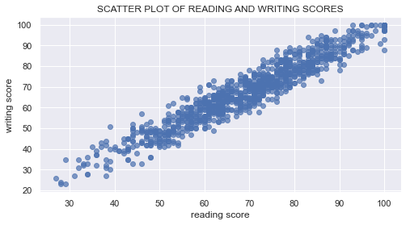

```python
plt.scatter(data=df, x='reading score', y='writing score', alpha=0.7)
plt.title('Scatter plot of reading and writing scores'.upper())
plt.xlabel('reading score')
plt.ylabel('writing score')
plt.show();
```

Students who did well in reading also did well in writing and those who did poorly in reading also did poorly in writing.

## Talk about some of the relationships you observed in this part of the investigation. How did the feature(s) of interest vary with other features in the dataset?

The analysis shows that parental level of education has a great impact on students performance. It was observed that children of parents with high education such as master's degree, bachelor's degree and associate degree performed better than children of parents with low education.

Expectedly, there is a very high linear correlation between reading score and writing score, indicating that a student who did well in one also did well in the other. Same goes with the math score and the other numerical variables.

More importantly, the analysis revealed that our variable of interest, test preparation course, had the expected impact on student performance as students who completed a test preparation course performed extremely better than those who did not.

## Did you observe any interesting relationships between the other features (not the main feature(s) of interest)?

It is observed that female students performed better than male students. However male students are better at math as shown in the analysis. Also, lunch had a very strong impact on students' performance: students who had standard lunch performed extremely better than those who had free/reduced lunch.

# MULTIVARIATE EXPLORATION

## Effects of gender and lunch on average score

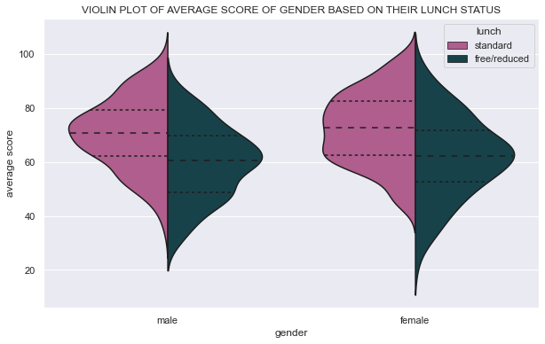

```python
multivariate_violin('average score', 'gender', 'lunch')
```

Students who had standard lunch (whether they are male or female) performed better than those who had free/reduced lunch.

## Effects of gender and test preparation course on average score

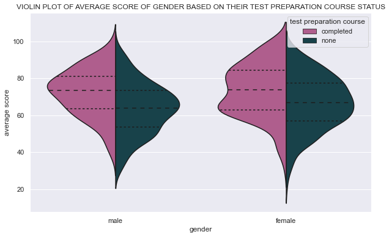

```python
multivariate_violin('average score', 'gender', 'test preparation course')
```

Students who completed a test preparation course (whether they are male or female) performed better than those who did not.

## Effects of lunch and test preparation course on average score

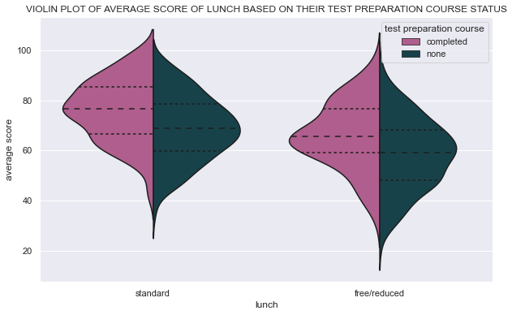

```python
multivariate_violin('average score', 'lunch', 'test preparation course')
```

Students who had standard lunch but did not undergo a test preparation course performed better than students who completed a test preparation course but had free or reduced lunch. This shows that lunch had a greater effect on students' performance than a test preparation course.